# Trabalho Prático 1 - Análise de Séries Temporais

Marcos Augusto Daza Barbosa, William Edward Rappel de Amorim

25 de Janeiro de 2023

# 1 **Introdução**

Neste trabalho, será realizado um estudo com o objetivo de ajustar modelos ARIMA e ETS aos dados de uma série temporal selecionada do banco de dados da competição de previsão M3, disponível no pacote `Mcomp`. A série escolhida para realizar essa análise é a com *id* igual a 1931.

Ela é uma série mensal, que descreve os envios de madeira. Possui 126 observações de treino, denominadas de parte *in-sample*, e 18 observações de teste, denominadas de parte *out-of-sample*.

A figura abaixo apresenta o comportamento observado desta série na amostra de treino, que inicia em Janeiro de 1982 e termina em Junho 1992.

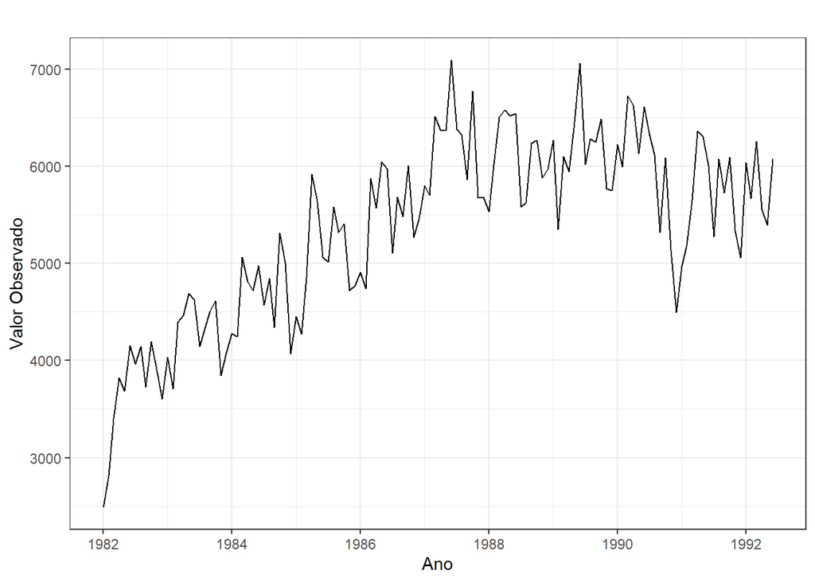

Figure 1.1: Comportamento da série ao longo do tempo.

Ao analisar a figura, parece existir uma tendência de crescimento ocorrida até 1988. Para entender mais profundamente o comportamento das componentes dessa série temporal, foi realizada uma decomposição via STL, por meio da função automática `mstl`.

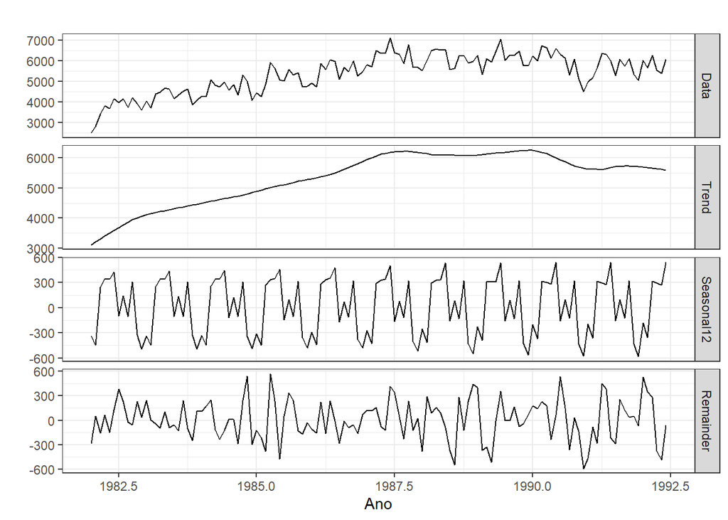

Figure 1.2: Decomposição STL da série.

A figura ilustra o resultado dessa decomposição. A componente de tendência (`Trend`) é inicialmente crescente e depois estabiliza, e é bastante relevante no valor da série (`Data`), pois sua escala varia de 3000 a 6000, enquanto a série original varia de 2000 a 7000. A componente de sazonalidade (`Seasonal12`) identificada pela função apresenta ciclo sazonal de tamanho 12, o que já era esperado por se tratar de uma série mensal. Essa componente aparenta ser aproximadamente constante ao longo da série, tendo uma escala variando de -600 a 600. Já a componente de ruído (`Remainder`) apresentou um bom comportamento na maior parte do tempo, similar a um ruído branco.

# 2 **Modelos ARIMA**

Nesta seleção, será realizado um procedimento de seleção e análise de modelos ARIMA ajustados nesta série temporal.

## 2.1 **Transformações**

O primeiro passo para determinar o melhor modelo a ser utilizado é entender quais transformações devem ser aplicadas para tornar a série original estacionária. Ao aplicar a função `ndiffs`, obtém-se o valor 1, ou seja, deve-se ser aplicada uma diferença simples e o `d` é igual a 1.

Em seguida, aplica-se a função `nsdiffs` ao resultado da primeira diferença simples. Ela retorna 0, ou seja, não serão necessárias diferenças sazonais. Dessa forma, `D` igual a 0.

A figura abaixo apresenta o comportamento observado da série original e da série diferenciada.

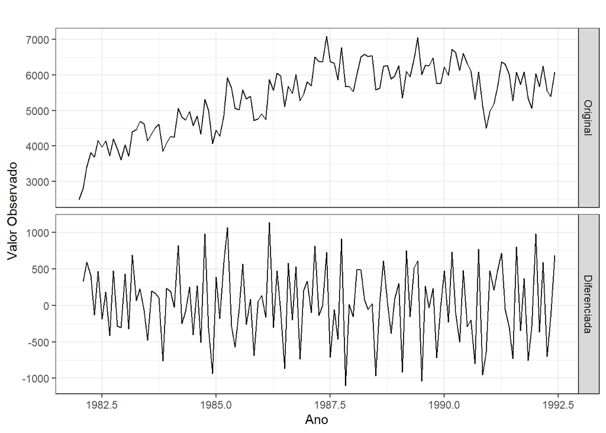

Figure 2.1: Diferenciação.

A série original é nitidamente não estacionária, e a série diferenciada aparenta ser, hipótese confirmada ao realizar o teste *Augmented Dickey-Fuller*.

```
##
##  Augmented Dickey-Fuller Test
##
## data:  .
## Dickey-Fuller = -6.7691, Lag order = 4, p-value = 0.01
## alternative hypothesis: stationary
```

## 2.2 **Seleção da ordem**

Para selecionar os parâmetros `p`, `q`, `P` e `Q`, deve-se investigar as autocorrelações e autocorrelações parciais.

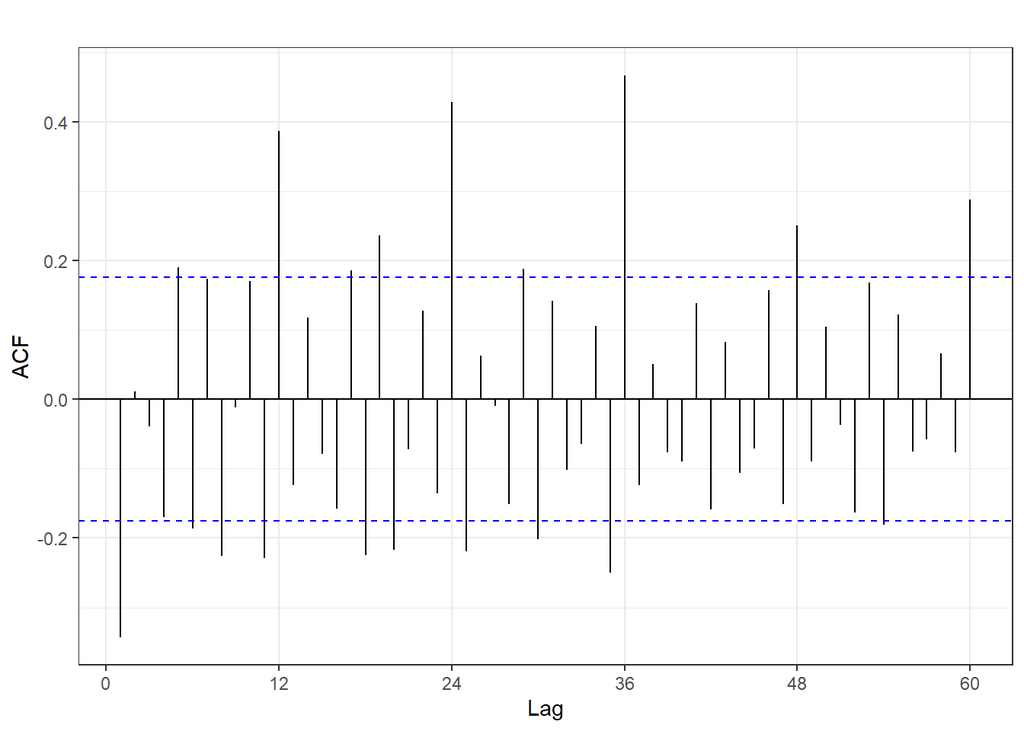

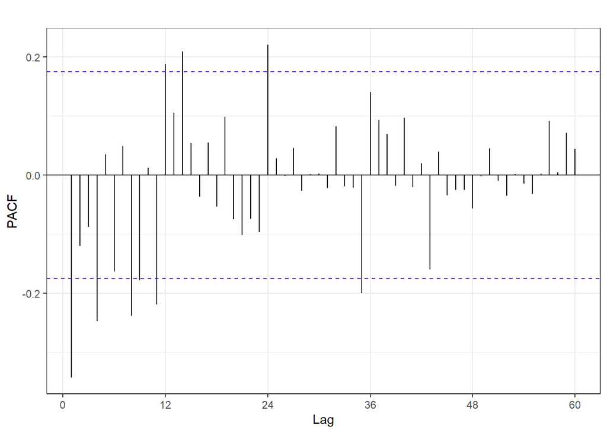

Figure 2.2: ACF e PACF.

Ao analisar o gráfico ACF, dentre as não sazonais, parece haver um valor mais significativo no primeiro *lag*, assim `q` igual a 1 é um bom palpite. Já ao investigar os *lags* sazonais, os mais significativos são 12, 24 e 36. Assim, serão consideradas como possibilidades para `Q` os valores 1, 2 e 3.

Já ao analisar o PACF, dentre os não sazonais, novamente o primeiro é o mais significativo, assim será utilizado `p` igual a 1. Para os sazonais, o *lag* 24 é o mais significativo. Dessa forma, serão consideradas como possibilidades para `P`: 0, 1 e 2.

Ao ajustar todos os modelos ARIMA correspondentes as combinações dos parâmetros `p`, `q`, `P` e `Q`, seleciona-se o modelo com menor AICc, que é apresentado abaixo.

```
## Series: .
## ARIMA(1,1,1)(1,0,2)[12]
##
## Coefficients:
##          ar1      ma1    sar1     sma1    sma2
##       0.2325  -0.7083  0.9747  -1.0288  0.2724
## s.e.  0.1337   0.0953  0.0244   0.1158  0.1025
##
## sigma^2 estimated as 112792:  log likelihood=-911.02
## AIC=1834.05   AICc=1834.76   BIC=1851.02
##
## Training set error measures:
##                     ME     RMSE      MAE        MPE     MAPE      MASE
## Training set -29.76627 327.7507 257.4193 -0.6064746 4.932637 0.4998602
##                     ACF1
## Training set 0.006708938
```

Dessa forma, foi selecionado o modelo `ARIMA(1,1,1)(1,0,2)[12]`, com AICc de 1834,76.

Em seguida, realiza-se o mesmo procedimento de seleção pelo AICc, só que agora considerando a transformação de Box-Cox, sendo que o parâmetro `lambda` é definido automaticamente por meio da heurística já implementada na função `Arima` do pacote `forecast`.

```
## Series: .
## ARIMA(1,1,1)(1,0,2)[12]
## Box Cox transformation: lambda= 0.6390879
##
## Coefficients:
##          ar1      ma1    sar1     sma1    sma2
##       0.2384  -0.6897  0.9768  -1.0504  0.2882
## s.e.  0.1400   0.1037  0.0213   0.1145  0.1026
##
## sigma^2 estimated as 227.9:  log likelihood=-523.72
## AIC=1059.44   AICc=1060.15   BIC=1076.41
##
## Training set error measures:
##                     ME     RMSE      MAE        MPE     MAPE      MASE
## Training set -35.99973 326.5198 260.4114 -0.7076345 4.977515 0.5056703
##                      ACF1
## Training set -0.008303924
```

Dessa forma, foi selecionado o modelo `ARIMA(1,1,1)(1,0,2)[12]`, com AICc de 1060,15 e o `lambda` escolhido igual a 0,64.

## 2.3 **Análise de resíduos**

Para analisar os resíduos, serão utilizadas abordagens gráficas e testes de hipóteses.

Primeiro, serão realizadas análises com o modelo ARIMA sem a transformação de Box-Cox.

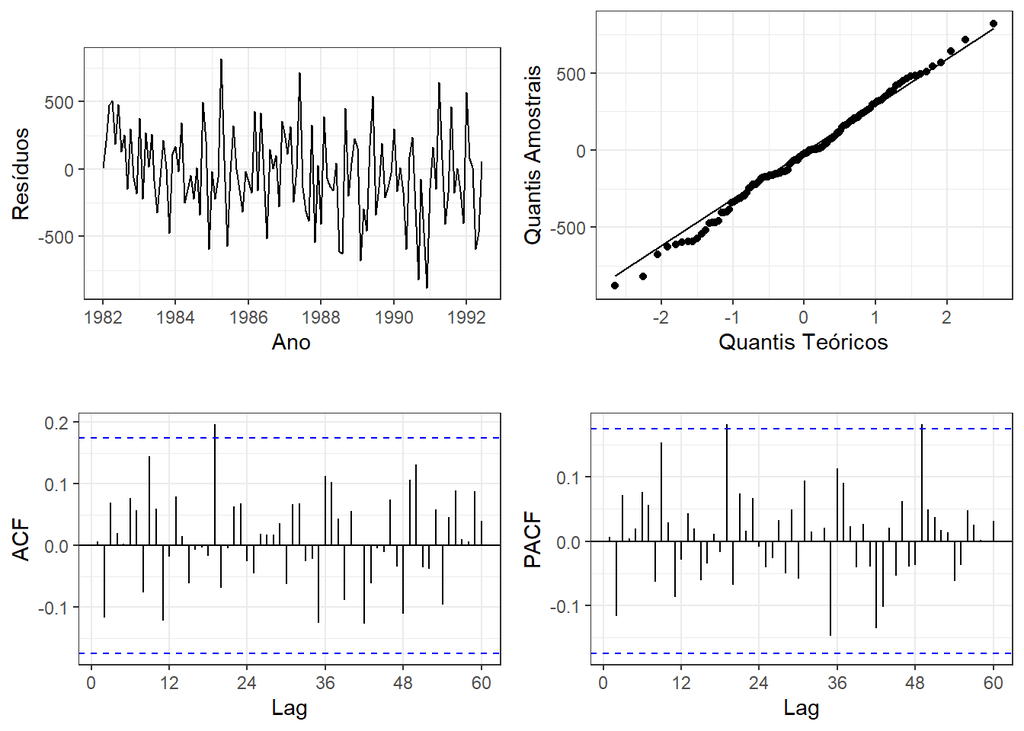

Figure 2.3: Análise de resíduos modelo ARIMA.

Ao avaliar o primeiro gráfico, os resíduos aparentam ser estacionários, tendo média zero e variância constante. Além disso, ao avaliar o *qqplot*, aparentam ser aproximadamente normais. Por último, por meio do ACF e PACF, nenhuma autocorrelação é muito siginificativa, sendo quase todas dentro da banda de não significância e, as poucas que saíram, estão bem próximas do limite.

Ao realizar os testes *Augmented Dickey-Fuller*, *Ljung-Box* e *Shapiro-Wilk*, conclui-se que os resíduos são estacionários, independentes e normais, respectivamente.

Agora, realiza-se procedimento semelhante, porém com o modelo ARIMA com a transformação de Box-Cox.

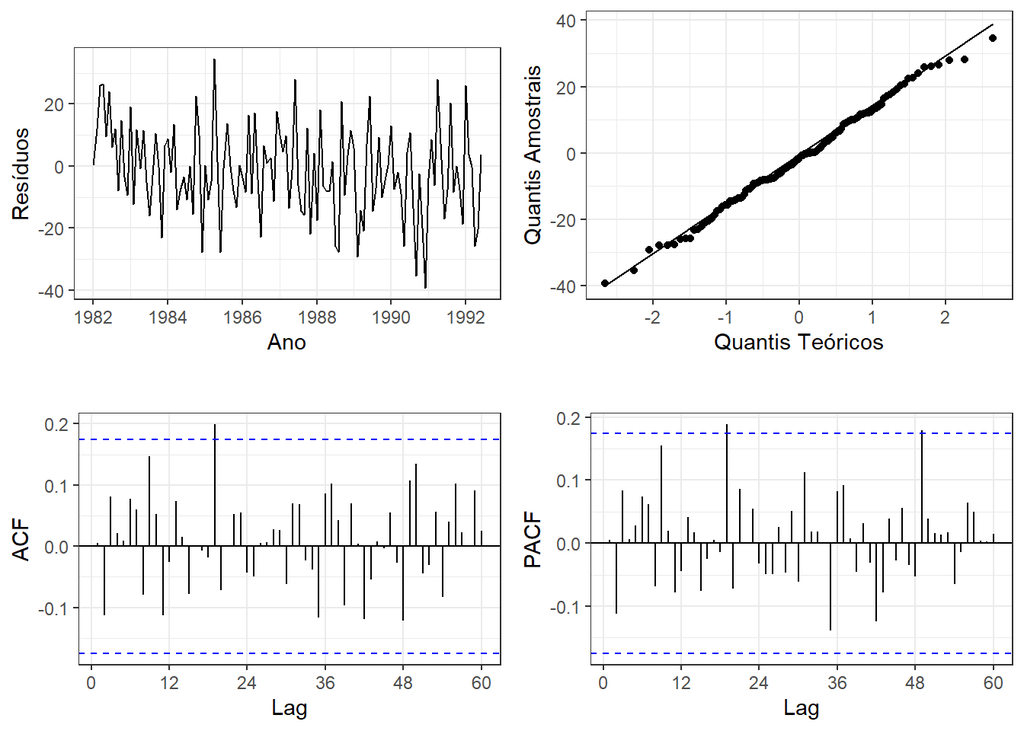

Figure 2.4: Análise de resíduos modelo ARIMA com Box-Cox.

As conclusões são muito semelhantes às obtidas anteriormente: os resíduos aparentam ser estacionários, normais e independentes. Ao realizar os testes *Augmented Dickey-Fuller*, *Ljung-Box* e *Shapiro-Wilk*, estas hipóteses são confirmadas.

# 3 **Modelos ETS**

Nesta seção, será realizado um procedimento de seleção e análise de modelos ETS ajustados nesta série temporal.

## 3.1 **Seleção**

Os modelos serão selecionados de forma automática, por meio da função `ets` do pacote `forecast`. Esse procedimento será realizado sem a transformação Box-Cox e, em seguida, com a aplicação dela considerando o parâmetro `lambda` definido automaticamente por meio da heurística já implementada na função.

```
## ETS(M,Ad,A)
##
## Call:
##  ets(y = .)
##
##   Smoothing parameters:
##     alpha = 0.3284
##     beta  = 1e-04
##     gamma = 1e-04
##     phi   = 0.9764
##
##   Initial states:
##     l = 3247.79
##     b = 74.4494
##     s = -537.9187 -342.2722 300.1228 -128.3485 121.0667 -113.7734
##            476.2259 368.1361 361.0313 269.9528 -432.5925 -341.6303
##
##   sigma:  0.0617
##
##      AIC     AICc      BIC
## 2085.694 2092.086 2136.747
##
## Training set error measures:
##                     ME     RMSE     MAE       MPE     MAPE      MASE      ACF1
## Training set -15.52275 305.1435 242.596 -0.552088 4.632971 0.4710763 0.1504657
```

O modelo sem Box-Cox selecionado é o ETS(M, Ad, A), ou seja, com erros multiplicativos, tendência aditiva com *damped* e sazonalidade aditiva. Ele apresenta AICc de 2092,09.

```
## ETS(A,Ad,A)
##
## Call:
##  ets(y = ., lambda = "auto")
##
##   Box-Cox transformation: lambda= 0.6391
##
##   Smoothing parameters:
##     alpha = 0.3428
##     beta  = 1e-04
##     gamma = 1e-04
##     phi   = 0.9735
##
##   Initial states:
##     l = 273.3698
##     b = 3.6225
##     s = -26.2316 -17.1407 14.1811 -4.6038 5.5424 -4.8251
##            20.9924 16.4844 15.7625 12.2844 -19.345 -13.1011
##
##   sigma:  14.7497
##
##      AIC     AICc      BIC
## 1305.299 1311.691 1356.352
##
## Training set error measures:
##                     ME     RMSE      MAE        MPE     MAPE      MASE
## Training set -7.975853 304.3027 240.8247 -0.4050985 4.597695 0.4676367
##                   ACF1
## Training set 0.1522253
```

O modelo com Box-Cox selecionado é o ETS(A, Ad, A), ou seja, com erros aditivos, tendência aditiva com *damped* e sazonalidade aditiva. Ele apresenta AICc de 1311,69 e teve *lambda* escolhido de 0,64.

## 3.2 **Análise de resíduos**

Primeiro, serão realizadas análises com o modelo ETS sem a transformação de Box-Cox.

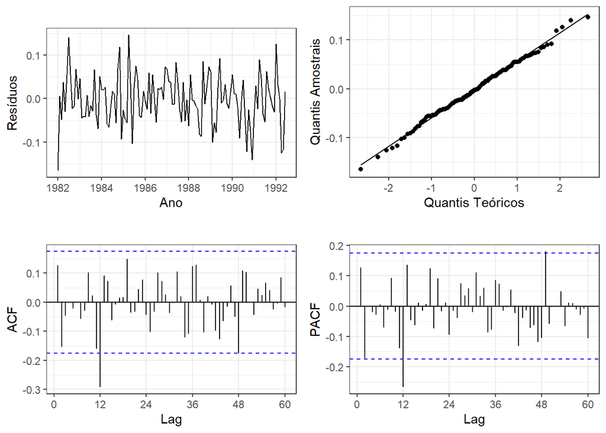

Figure 3.1: Análise de resíduos modelo ETS.

Por meio do primeiro gráfico, os resíduos aparentam ser estacionários, tendo média zero e variância constante. Já o *qqplot* demonstra provável normalidade. Porém, os gráficos ACF e PACF, apresentam um valor bastante significativo no *lag* 12. Por meio do testes, confirma-se essas hipóteses: os resíduos são estacionários, normais e **não** independentes.

Agora, será avaliado o modelo ETS com transformação Box-Cox.

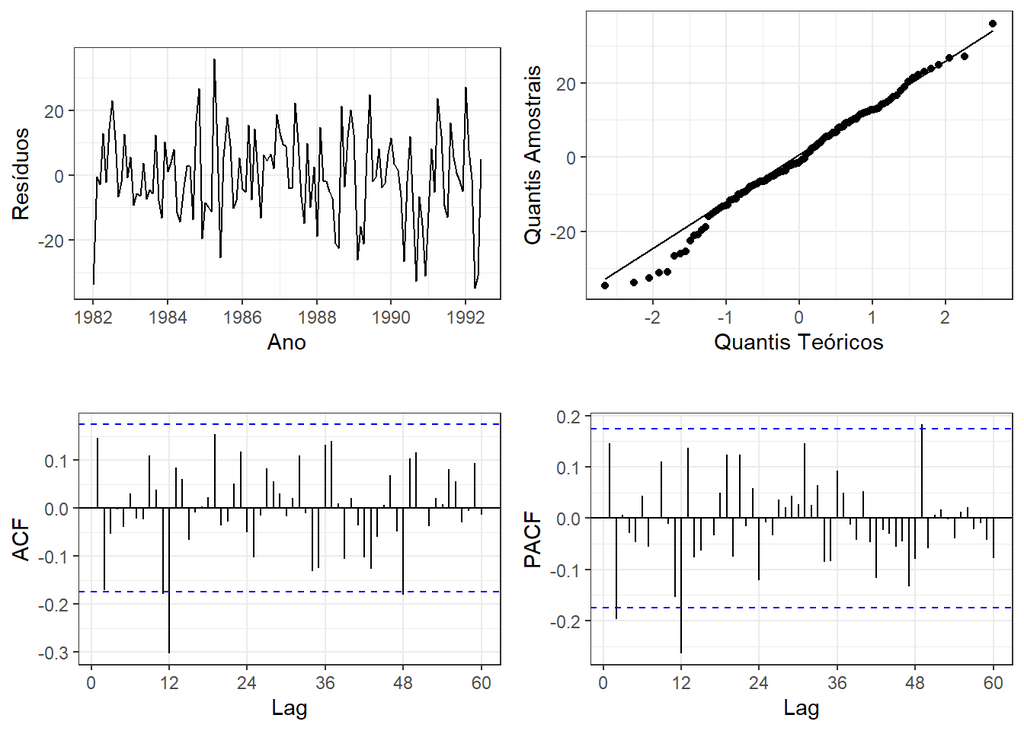

Figure 3.2: Análise de resíduos modelo ETS.

As conclusões são idênticas às obtidas com o modelo ETS sem a transformação Box-Cox: apesar de serem estacionários e normais, os resíduos apresentam **não** independência.

# 4 **Estudo do desempenho preditivo**

Nesta seção, será realizado um estudo da performance preditiva dos 4 modelos candidatos apresentados anteriormente, utilizando uma janela deslizante, iniciando no ponto `n-14` e considerando horizontes de predição até 5 passos à frente.

A tabela e figura abaixo apresentam os resultados de erro absoluto médio obtido por cada modelo, para cada horizonte de predição.

Table 4.1: MAE por horizonte de predição.

|  | ARIMA | ARIMA + Box-Cox | ETS | ETS + Box-Cox |
| --- | --- | --- | --- | --- |
| h=1 | 295 | 302 | 298 | 338 |
| h=2 | 348 | 359 | 356 | 403 |
| h=3 | 355 | 373 | 371 | 434 |
| h=4 | 328 | 352 | 335 | 406 |
| h=5 | 323 | 349 | 311 | 339 |

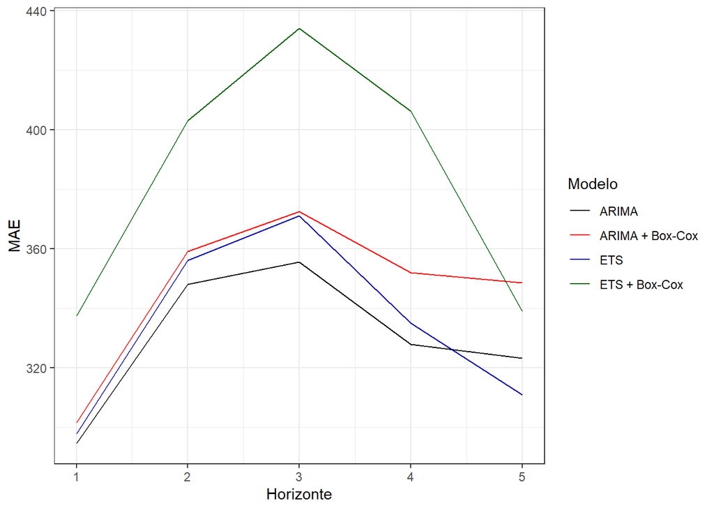

Figure 4.1: Desempenho preditivo por horizonte de predição.

A partir da análise da tabela e do gráfico, tem-se que para os primeiros 4 horizontes de predição, o modelo mais preciso é o ARIMA, seguido pelo ETS, depois pelo ARIMA + Box-Cox e, por último, o ETS + Box-Cox. Já no horizonte 5, a ordem se altera: o ETS troca com o ARIMA e o ETS + Box-Cox troca com o ARIMA + Box-Cox.

# 5 **Resultados**

Nesta seção, serão obtidas previsões pontuais e intervalares de 95% com os 4 modelos candidatos selecionados. Em seguida, o desempenho nos dados de testes serão comparados com de alguns *benchmarks*.

A tabela abaixo apresenta as previsões pontuais de cada um dos 4 modelos, além dos dados observados de teste.

Table 5.1: Previsões pontuais por horizonte de predição.

|  | 1 | 2 | 3 | 4 | 5 | 6 | 7 | 8 | 9 | 10 | 11 | 12 | 13 | 14 | 15 | 16 | 17 | 18 |
| --- | --- | --- | --- | --- | --- | --- | --- | --- | --- | --- | --- | --- | --- | --- | --- | --- | --- | --- |
| Observado | 5926 | 5936 | 5568 | 6216 | 5624 | 5148 | 5328 | 5524 | 5584 | 5162 | 4880 | 5452 | 5760 | 5970 | 5426 | 6256 | 5450 | 5424 |
| ARIMA | 5479 | 5553 | 5404 | 5809 | 5144 | 5028 | 5276 | 5154 | 5757 | 5909 | 5887 | 6059 | 5437 | 5659 | 5411 | 5817 | 5127 | 4926 |
| ARIMA + Box-Cox | 5478 | 5544 | 5404 | 5804 | 5152 | 5041 | 5270 | 5154 | 5753 | 5913 | 5900 | 6061 | 5444 | 5665 | 5421 | 5825 | 5142 | 4939 |
| ETS | 5424 | 5662 | 5416 | 5848 | 5208 | 5016 | 5215 | 5127 | 5832 | 5926 | 5936 | 6047 | 5459 | 5697 | 5450 | 5881 | 5241 | 5047 |
| ETS + Box-Cox | 5415 | 5650 | 5424 | 5851 | 5152 | 4957 | 5245 | 5111 | 5819 | 5900 | 5919 | 6025 | 5440 | 5675 | 5449 | 5875 | 5175 | 4979 |

Já a tabela abaixo apresenta as previsões intervalares com 95% de confiança.

Table 5.2: Previsões intervalares de 95% de confiança por horizonte de predição.

|  | 1 | 2 | 3 | 4 | 5 | 6 | 7 | 8 | 9 | 10 | 11 | 12 | 13 | 14 | 15 | 16 | 17 | 18 |
| --- | --- | --- | --- | --- | --- | --- | --- | --- | --- | --- | --- | --- | --- | --- | --- | --- | --- | --- |
| Observado | 5926 | 5936 | 5568 | 6216 | 5624 | 5148 | 5328 | 5524 | 5584 | 5162 | 4880 | 5452 | 5760 | 5970 | 5426 | 6256 | 5450 | 5424 |
| ARIMA Inf | 4821 | 4810 | 4612 | 4977 | 4275 | 4124 | 4338 | 4183 | 4754 | 4875 | 4824 | 4966 | 4323 | 4522 | 4250 | 4632 | 3918 | 3694 |
| ARIMA Sup | 6138 | 6296 | 6195 | 6641 | 6013 | 5933 | 6214 | 6125 | 6759 | 6942 | 6950 | 7151 | 6550 | 6796 | 6572 | 7003 | 6335 | 6157 |
| ARIMA + Box-Cox Inf | 4831 | 4805 | 4621 | 4956 | 4303 | 4163 | 4342 | 4200 | 4724 | 4841 | 4797 | 4915 | 4326 | 4507 | 4259 | 4606 | 3958 | 3753 |
| ARIMA + Box-Cox Sup | 6154 | 6320 | 6230 | 6700 | 6055 | 5979 | 6262 | 6176 | 6852 | 7061 | 7083 | 7290 | 6652 | 6917 | 6682 | 7144 | 6433 | 6238 |
| ETS Inf | 4768 | 4944 | 4690 | 5045 | 4437 | 4235 | 4391 | 4284 | 4902 | 4959 | 4939 | 5013 | 4445 | 4641 | 4388 | 4764 | 4146 | 3946 |
| ETS Sup | 6080 | 6381 | 6142 | 6651 | 5980 | 5797 | 6040 | 5970 | 6763 | 6894 | 6933 | 7081 | 6474 | 6753 | 6512 | 6997 | 6335 | 6149 |
| ETS + Box-Cox Inf | 4785 | 4974 | 4726 | 5100 | 4407 | 4194 | 4438 | 4285 | 4925 | 4976 | 4968 | 5043 | 4472 | 4668 | 4436 | 4810 | 4140 | 3940 |
| ETS + Box-Cox Sup | 6072 | 6356 | 6157 | 6639 | 5939 | 5765 | 6100 | 5987 | 6765 | 6880 | 6929 | 7069 | 6475 | 6751 | 6535 | 7015 | 6290 | 6103 |

As figuras abaixo ilustram o comportamento dessas previsões, conjutamente com o comportamento observado nos dados de teste.

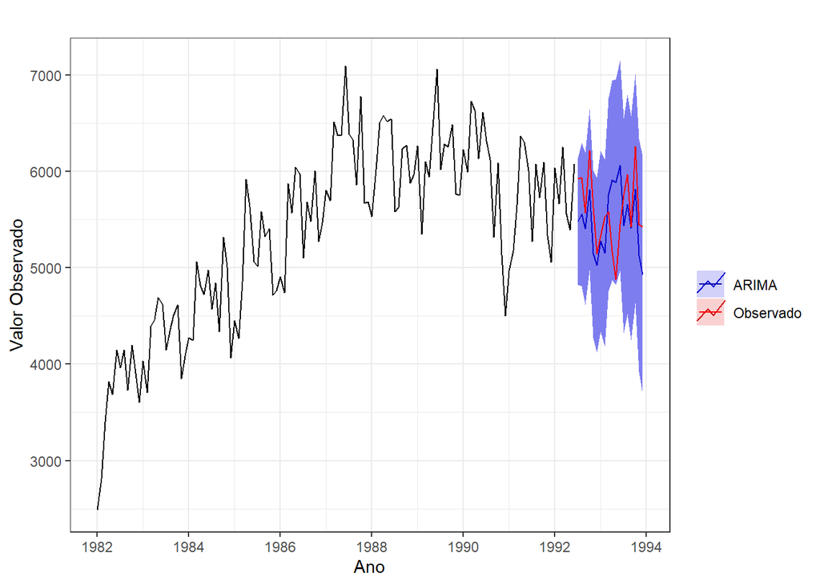

Figure 5.1: Previsão pontual e intervalar do ARIMA.

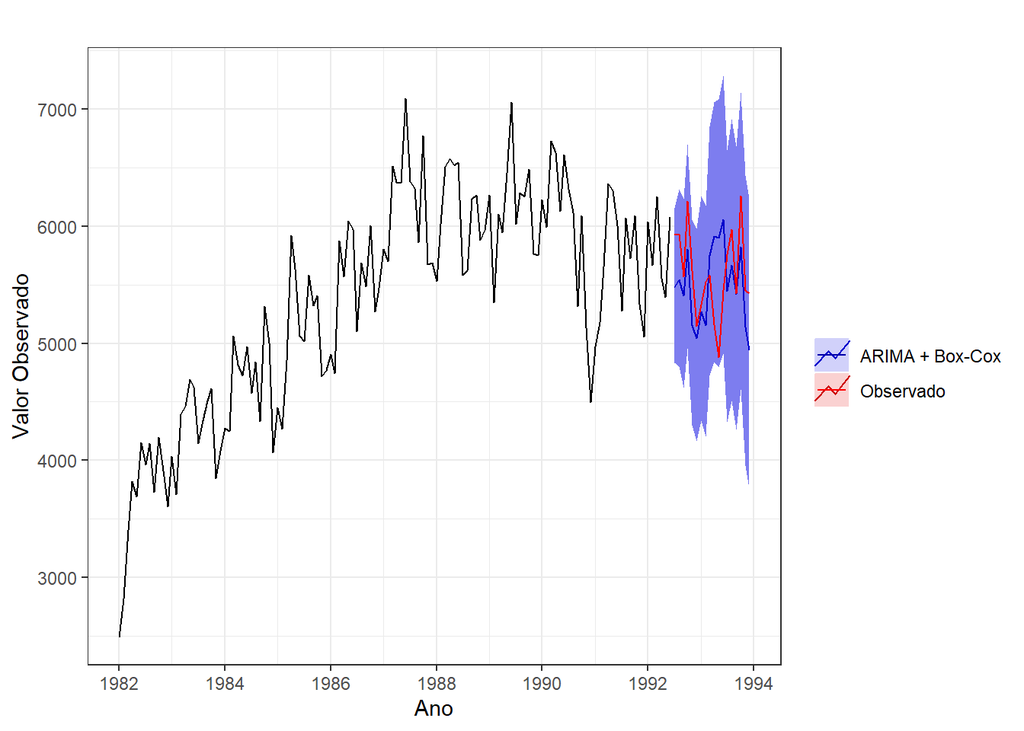

Figure 5.2: Previsão pontual e intervalar do ARIMA + Box-Cox.

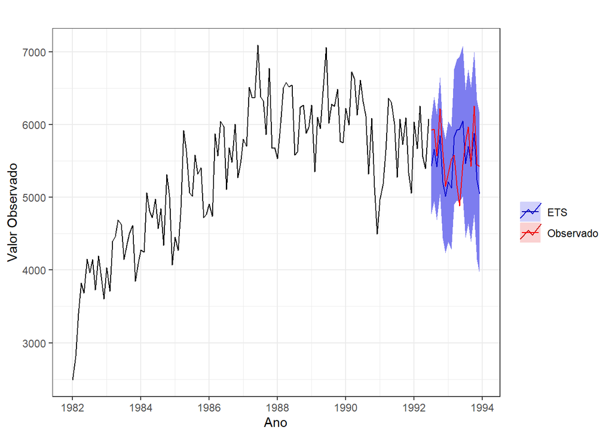

Figure 5.3: Previsão pontual e intervalar do ETS.

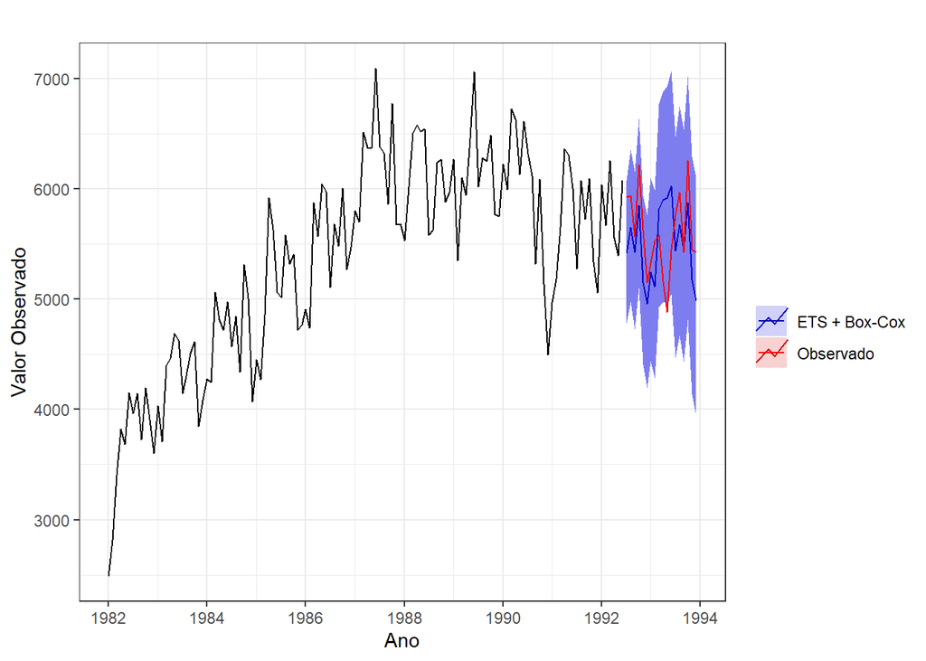

Figure 5.4: Previsão pontual e intervalar do ETS + Box-Cox.

Por meio da análise dos gráficos, todos os modelos apresentaram previsões pontuais razoáveis e previsões intervalares com bom grau de cobertura dos dados verdadeiros de teste.

Agora, serão realizadas as comparações com os *benchmarks*.

Table 5.3: MAE nos dados de teste.

|  | MAE |
| --- | --- |
| ARIMA | 381 |
| ARIMA + Box-Cox | 379 |
| ETS | 365 |
| ETS + Box-Cox | 377 |
| auto.arima | 499 |
| SES | 367 |
| Holt | 518 |
| sltf | 385 |
| BATS | 332 |
| TBATS | 332 |
| Bagged ETS | 313 |

Ao avaliar a tabela acima, percebe-se que apesar do ARIMA ter tido o melhor desempenho na análise de janela deslizante, o candidato com melhor desempenho no teste foi o ETS. Além disso, o ARIMA + Box-Cox foi mais preciso do que o ARIMA sem a transformação. O ETS foi superior a 4 *benchmarks*: `auto.arima`, `ses`, `holt` e `stlf`. Já BATS, TBATS e *Bagged* ETS foram superiores ao ETS, sendo que o *Bagged* ETS foi consideravelmente mais preciso que todos os demais.

# 6 **Conclusão**

A partir dos 4 modelos candidatos obtidos, os 2 modelos ARIMA apresentaram resíduos com todas as características esperadas, já os resíduos dos 2 modelos ETS apresentaram não independência.

Em relação à analise do desempenho preditivo obtido pela janela deslizante, em geral os modelos com transformação Box-Cox apresentaram pior performance do que os sem essa transformação. Além disso, os ARIMAs foram mais precisos do que os ETS.

Contudo, ao avaliar o desempenho preditivo por meio dos valores de teste, os modelos ETS foram mais precisos que ambos os ARIMAs, sendo que o ETS sem a transformação Box-Cox teve o melhor desempenho dentre os 4 candidatos.

Já na comparação com os *benchmarks*, o BATS, TBATS e *Bagged* ETS foram superiores aos 4 modelos candidatos e aos demais *benchmarks*, com destaque para o *Bagged* ETS, que teve o menor MAE dentre todos.

# 7 **Anexo: Código R**

```r
### Reproducibility
set.seed(10)


### Packages
pacman::p_load(Mcomp, tidyverse, forecast, tseries, knitr, cowplot, kableExtra, forecTheta)


### Data
data(M3)
id <- 1931
period <- M3[[id]]$period
description <- M3[[id]]$description
x <- M3[[id]]$x
n <- M3[[id]]$n
h <- M3[[id]]$h
xx <- M3[[id]]$xx


### Time series plot
x %>%
  autoplot() +
  labs(x='Ano', y='Valor Observado') +
  theme_bw()


### STL decomposition
x %>%
  mstl() %>%
  autoplot() +
  labs(x='Ano') +
  theme_bw()


### ARIMA
# Diffs
diffs <- c()
if (x %>% ndiffs() == 1) {
  w <- diff(x)
  diffs <- c(diffs, 1)
  if (w %>% nsdiffs() == 1) {
    w <- diff(w, lag=12)
    diffs <- c(diffs, 12)
  }
}
cbind(Original=x, Diferenciada=w) %>%
  autoplot(facets=T) +
  labs(x='Ano', y='Valor Observado') +
  theme_bw()
w %>% adf.test()
# Manual selection
w %>%
  ggAcf(lag.max=12*5) +
  labs(title='') +
  theme_bw()
w %>%
  ggPacf(lag.max=12*5) +
  labs(title='') +
  theme_bw()
# p = 1
# q = 1
# P = 0, 1 ou 2
# Q = 1, 2 ou 3
p <- 1
q <- 1
P <- 0:2
Q <- 1:3
# Without Box-Cox
best_aicc <- Inf
for (Pi in P) {
  for (Qi in Q) {
    mod <- x %>% Arima(order=c(1, 1, 1), seasonal=c(Pi, 0, Qi), include.mean=F, lambda=NULL)
    if (mod$aicc < best_aicc) {
      best_mod <- mod
      best_aicc <- mod$aicc
    }
  }
}
mod1 <- best_mod
mod1 %>% summary()
# With Box-Cox
best_aicc <- Inf
for (Pi in P) {
  for (Qi in Q) {
    mod <- x %>% Arima(order=c(1, 1, 1), seasonal=c(Pi, 0, Qi), include.mean=F, lambda='auto')
    if (mod$aicc < best_aicc) {
      best_mod <- mod
      best_aicc <- mod$aicc
    }
  }
}
mod2 <- best_mod
mod2 %>% summary()
# Residual analysis without Box-Cox
res1 <- mod1 %>% residuals()
est1 <- res1 %>%
  autoplot() +
  labs(x='Ano', y='Resíduos') +
  theme_bw()
qq1 <- res1 %>%
  data.frame() %>%
  ggplot(aes(sample=res1)) +
  stat_qq() +
  stat_qq_line() +
  labs(x='Quantis Teóricos', y='Quantis Amostrais') +
  theme_bw()
acf1 <- res1 %>%
  ggAcf(lag.max=12*5) +
  labs(title='') +
  theme_bw()
pacf1 <- res1 %>%
  ggPacf(lag.max=12*5) +
  labs(title='') +
  theme_bw()
plot_grid(est1, qq1, acf1, pacf1, nrow=2)
res1 %>% adf.test()
res1 %>% Box.test(lag=20, type='Ljung-Box', fitdf=5)
res1 %>% shapiro.test()
mod1 %>% checkresiduals()
# Residual analysis with Box-Cox
res2 <- mod2 %>% residuals()
est2 <- res2 %>%
  autoplot() +
  labs(x='Ano', y='Resíduos') +
  theme_bw()
qq2 <- res2 %>%
  data.frame() %>%
  ggplot(aes(sample=res2)) +
  stat_qq() +
  stat_qq_line() +
  labs(x='Quantis Teóricos', y='Quantis Amostrais') +
  theme_bw()
acf2 <- res2 %>%
  ggAcf(lag.max=12*5) +
  labs(title='') +
  theme_bw()
pacf2 <- res2 %>%
  ggPacf(lag.max=12*5) +
  labs(title='') +
  theme_bw()
plot_grid(est2, qq2, acf2, pacf2, nrow=2)
res2 %>% adf.test()
res2 %>% Box.test(lag=20, type='Ljung-Box', fitdf=5)
res2 %>% shapiro.test()
mod2 %>% checkresiduals()


### ETS
# Auto selection without Box-Cox
mod3 <- x %>% ets()
mod3 %>% summary()
# Auto selection with Box-Cox
mod4 <- x %>% ets(lambda='auto')
mod4 %>% summary()
# Residual analysis without Box-Cox
res3 <- mod3 %>% residuals()
est3 <- res3 %>%
  autoplot() +
  labs(x='Ano', y='Resíduos') +
  theme_bw()
qq3 <- res3 %>%
  data.frame() %>%
  ggplot(aes(sample=res3)) +
  stat_qq() +
  stat_qq_line() +
  labs(x='Quantis Teóricos', y='Quantis Amostrais') +
  theme_bw()
acf3 <- res3 %>%
  ggAcf(lag.max=12*5) +
  labs(title='') +
  theme_bw()
pacf3 <- res3 %>%
  ggPacf(lag.max=12*5) +
  labs(title='') +
  theme_bw()
plot_grid(est3, qq3, acf3, pacf3, nrow=2)
res3 %>% adf.test()
res3 %>% Box.test(lag=20, type='Ljung-Box', fitdf=17)
res3 %>% shapiro.test()
mod3 %>% checkresiduals()
# Residual analysis with Box-Cox
res4 <- mod4 %>% residuals()
est4 <- res4 %>%
  autoplot() +
  labs(x='Ano', y='Resíduos') +
  theme_bw()
qq4 <- res4 %>%
  data.frame() %>%
  ggplot(aes(sample=res4)) +
  stat_qq() +
  stat_qq_line() +
  labs(x='Quantis Teóricos', y='Quantis Amostrais') +
  theme_bw()
acf4 <- res4 %>%
  ggAcf(lag.max=12*5) +
  labs(title='') +
  theme_bw()
pacf4 <- res4 %>%
  ggPacf(lag.max=12*5) +
  labs(title='') +
  theme_bw()
plot_grid(est4, qq4, acf4, pacf4, nrow=2)
res4 %>% adf.test()
res4 %>% Box.test(lag=20, type='Ljung-Box', fitdf=17)
res4 %>% shapiro.test()
mod4 %>% checkresiduals()


### Sliding window validation
f_arima1 <- function(y, h){
  fit <- Arima(y, order=c(1, 1, 1), seasonal=c(1, 0, 2), include.mean=F, lambda=NULL)
  forecast(fit, h)
}
f_arima2 <- function(y, h){
  fit <- Arima(y, order=c(1, 1, 1), seasonal=c(1, 0, 2), include.mean=F, lambda='auto')
  forecast(fit, h)
}
f_ets1 <- function(y, h){
  fit <- ets(y)
  forecast(fit, h)
}
f_ets2 <- function(y, h){
  fit <- ets(y, lambda='auto')
  forecast(fit, h)
}
CV_arima1 <- x %>% tsCV(forecastfunction=f_arima1, h=5, initial=n-14)
CV_arima2 <- x %>% tsCV(forecastfunction=f_arima2, h=5, initial=n-14)
CV_ets1 <- x %>% tsCV(forecastfunction=f_ets1, h=5, initial=n-14)
CV_ets2 <- x %>% tsCV(forecastfunction=f_ets2, h=5, initial=n-14)
MAE_arima1 <- CV_arima1 %>% abs() %>% colMeans(na.rm=T)
MAE_arima2 <- CV_arima2 %>% abs() %>% colMeans(na.rm=T)
MAE_ets1 <- CV_ets1 %>% abs() %>% colMeans(na.rm=T)
MAE_ets2 <- CV_ets2 %>% abs() %>% colMeans(na.rm=T)
tab <- cbind(MAE_arima1, MAE_arima2, MAE_ets1, MAE_ets2)
tab %>%
  kable(
    col.names=c('ARIMA', 'ARIMA + Box-Cox', 'ETS', 'ETS + Box-Cox'),
    caption='MAE por horizonte de predição.',
    digits=0,
    format.args=list(decimal.mark=',', scientific=F),
    align='c'
  ) %>%
  kable_styling(
    position='center',
    bootstrap_options=c('striped', 'hover', 'condensed', 'responsive')
  )
tab_plot <- tab %>%
  as.data.frame() %>%
  mutate(Horizonte=1:5) %>%
  gather(key='Modelo', value='MAE', -Horizonte)
tab_plot %>%
  ggplot(aes(x=Horizonte, y=MAE)) +
  geom_line(aes(color=Modelo)) +
  scale_color_manual(
    values=c('black', 'red', '#0000AA', 'darkgreen'),
    breaks=c('MAE_arima1', 'MAE_arima2', 'MAE_ets1', 'MAE_ets2'),
    labels=c('ARIMA', 'ARIMA + Box-Cox', 'ETS', 'ETS + Box-Cox')
    ) +
  theme_bw()


### Forecast
# tables
preds1 <- forecast(mod1, h=h, level=95)
preds2 <- forecast(mod2, h=h, level=95)
preds3 <- forecast(mod3, h=h, level=95)
preds4 <- forecast(mod4, h=h, level=95)
pontual <- t(cbind(xx, preds1$mean, preds2$mean, preds3$mean, preds4$mean))
colnames(pontual) <- 1:h
row.names(pontual) <- c('Observado', 'ARIMA', 'ARIMA + Box-Cox', 'ETS', 'ETS + Box-Cox')
pontual %>%
  kable(
    caption='Previsões pontuais por horizonte de predição.',
    digits=0,
    format.args=list(decimal.mark=',', scientific=F),
    align='c'
  ) %>%
  kable_styling(
    position='center',
    bootstrap_options=c('striped', 'hover', 'condensed', 'responsive')
  )
intervalares <- t(cbind(xx, preds1$lower, preds1$upper, preds2$lower, preds2$upper,
                        preds3$lower, preds3$upper, preds4$lower, preds4$upper))
colnames(intervalares) <- 1:h
row.names(intervalares) <- c('Observado', 'ARIMA Inf', 'ARIMA Sup', 'ARIMA + Box-Cox Inf',
                             'ARIMA + Box-Cox Sup', 'ETS Inf', 'ETS Sup', 'ETS + Box-Cox Inf',
                             'ETS + Box-Cox Sup')
intervalares %>%
  kable(
    caption='Previsões intervalares de 95% de confiança por horizonte de predição.',
    digits=0,
    format.args=list(decimal.mark=',', scientific=F),
    align='c'
  ) %>%
  kable_styling(
    position='center',
    bootstrap_options=c('striped', 'hover', 'condensed', 'responsive')
  )
# plots
plot_preds <- function(mod, nome='') {
  vec <- c(nome, 'Observado')
  cores <- c('#0000AA', 'red')
  names(cores) <- vec
  preds <- forecast(mod, h=h, level=95)
  plot_obj <- x %>%
    autoplot() + xlab('Ano') + ylab('Valor Observado') + theme_bw() +
    autolayer(preds, series=nome) +
    autolayer(xx, series='Observado') +
    scale_colour_manual(
      values=cores,
      breaks=vec,
      name='')
  return(plot_obj)
}
plot_preds(mod1, 'ARIMA')
plot_preds(mod2, 'ARIMA + Box-Cox')
plot_preds(mod3, 'ETS')
plot_preds(mod4, 'ETS + Box-Cox')
# Benchmark comparison
preds <- list(
  'ARIMA' = forecast(mod1, h=h),
  'ARIMA + Box-Cox' = forecast(mod2, h=h),
  'ETS' = forecast(mod3, h=h),
  'ETS + Box-Cox' = forecast(mod4, h=h),
  'auto.arima' = forecast(auto.arima(x), h=h),
  'SES' = ses(x, h=h),
  'Holt' = holt(x, h=h),
  'sltf' = stlf(x, h=h),
  'BATS' = forecast(bats(x), h=h),
  'TBATS' = forecast(tbats(x), h=h),
  'Bagged ETS' = forecast(baggedETS(x), h=h)
)
mae <- unlist(lapply(preds, function(m) return(mean(abs(xx - m$mean)))))
final <- data.frame(MAE=mae)
final %>%
  kable(
    caption='MAE nos dados de teste.',
    digits=0,
    format.args=list(decimal.mark=',', scientific=F),
    align='c'
  ) %>%
  kable_styling(
    position='center',
    bootstrap_options=c('striped', 'hover', 'condensed', 'responsive')
  )
```